# Residuals and Diagnostics for Binary and Ordinal Regression Models: An Introduction to the sure Package

### 3.2 Detecting heteroscedasticty

One issue that often raises concerns in statistical inference is that of heteroscedasticity; that is, when the error term has non constant variance. Heteroscedasticity can bias the statistical inference and lead to improper standard errors, confidence intervals, and $p$-values. Therefore, it is imperative to identify heteroscedasticity whenever present and take appropriate action (e.g., transformations). In ordinary linear regression, this topic has been covered extensively. Not much has been proposed in the literature for categorical models.

As discussed in Section “2,” one of the properties of the surrogate residual $R_S$ is that, if the model is specified correctly, then $Var\left(R_S | X\right) = c$, where $c$ is a constant.

For this example, we generated $n = 2000$ observations from the following ordered probit model:
$$Pr\left\{\mathcal{Y} \le j\right\} = \Phi\left\{\left(\alpha_j + \beta X\right) / \sigma_X\right\}, \quad j = 1, 2, 3, 4, 5,$$
where $\alpha_1 = -36$, $\alpha_2 = -6$, $\alpha_3 = 34$, $\alpha_4 = 64$, $\beta = -4$, $X \sim \mathcal{U}\left(2, 7\right)$, and $\sigma_X = X ^ 2$. Notice how the variability is an increasing function of $X$. These data are available in the `df2` data frame loaded with the *sure* package; see `?df2` for details.

The following block of code uses the `orm` function from the popular *rms* package to fit a probit model to the simulated data. Note: we set `x = TRUE` in the call to `orm` in order to use the `presid` function later.

```r
# Fit a cumulative link model with probit link
library(rms)  # for orm function
fit.orm <- orm(y ~ x, data = df2, family = "probit", x = TRUE)
```

If heteroscedasticity is present, we would expect this to show up in various diagnostic plots, such as a residual-vs-covariate plot. Below we obtain the SBS and surrogate residuals as before and plot them against $X$. The results are displayed in Figure 4.

```r
set.seed(102)  # for reproducibility
p1 <- autoplot(resids(fit.orm), what = "covariate", x = df2$x, xlab = "x")
p2 <- ggplot(data.frame(x = df2$x, y = presid(fit.orm)), aes(x, y)) +
  geom_point(color = "#444444", shape = 19, size = 2, alpha = 0.25) +
  geom_smooth(col = "red", se = FALSE) +
  ylab("Probability scale residual")
grid.arrange(p1, p2, ncol = 2)  # Figure 4
```

In Figure 4, it is clear from the plot of the surrogate residuals (left side of Figure 4) that the variance increases with $X$, a sign of heteroscedasticity. As a matter of fact, the plot suggests that the true link function has a varying scale parameter, $\sigma = \sigma\left(\boldsymbol{X}\right)$. The plot of the SBS residuals (right side of Figure 4), on the other hand, gives no indication of an issue with nonconstant variance.

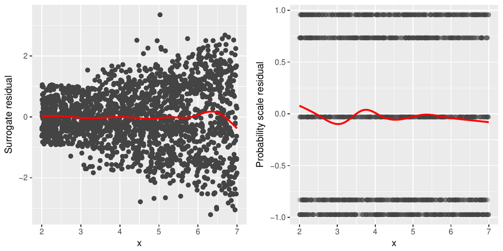

Figure 4: Residual-vs-covariate plots with nonparametric smooths (red curves) for the simulated heteroscedastic data. *Left*: Surrogate residuals. *Right*: SBS residuals.

As outlined in Section “2.1,” the jittering technique is broadly applicable to virtually all parametric and nonparametric models for ordinal responses. To illustrate, the code chunk below uses the *VGAM* package to fit a vector generalized additive model to the same data using a nonparametric smooth for $x$.

```r
library(VGAM)  # for vgam and vglm functions
fit.vgam <- vgam(y ~ s(x), family = cumulative(link = probit, parallel = TRUE),
                 data = df2)
```

To obtain a surrogate residual using the jittering technique, we can set `method = "jitter"` in the call to `resids` or `autoplot`. There is also the option `jitter.scale` which can be set to either `"probability"`, for jittering on the probability scale (the default), or `"response"`, for jittering on the response scale. In the code chunk below, we use the `autoplot` function to obtain residual-by-covariate plots using both types of jittering. The results (Figure 5) indicate that the variance increases with increasing $x$.

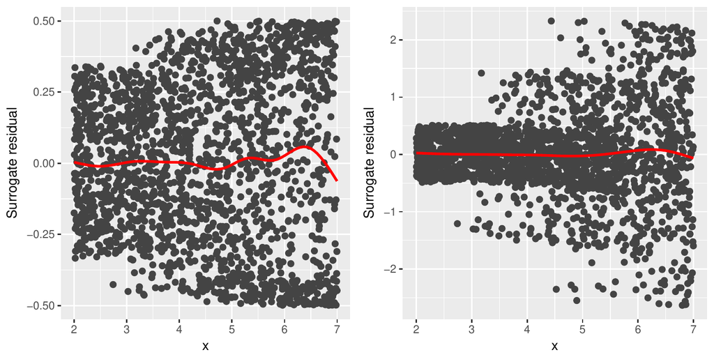

Figure 5: Residual-vs-covariate plots with nonparametric smooths (red curves) from a vector generalized additive model fit to the simulated heteroscedastic data. *Left*: Jittering on the probability scale (default). *Right*: Jittering on the response scale.

```r
set.seed(103)  # for reproducibility
p1 <- autoplot(fit.vgam, what = "covariate", x = df2$x, method = "jitter",
               xlab = "x")
p2 <- autoplot(fit.vgam, what = "covariate", x = df2$x, method = "jitter",
               jitter.scale = "response", xlab = "x")
grid.arrange(p1, p2, ncol = 2)  # Figure 5
```

### 3.3 Detecting a misspecified link function

For this example, we simulated $n = 2000$ observations from the following model
$$Pr\left(\mathcal{Y} \le j\right) = G\left(\alpha_j - 8 X + X ^ 2\right), \quad j = 1, 2, 3, 4,$$
where $G\left(\cdot\right)$ is the CDF for the Gumbel (max) distribution (see Table 1), $\alpha_1 = -16$, $\alpha_2 = -12$, $\alpha_3 = -8$, $\beta_1 = -8$, $\beta_2 = 1$, and $X \sim \mathcal{U}\left(1, 7\right)$. The data are available in the data frame `df3` within the package; see `?df3` for details.

We fit a model with various link functions, where the true link function is log-log. From these output, we construct Q-Q plots of the residuals using $R = 100$ bootstrap replicates. The results are displayed in Figure 6.

```r
# Fit models with various link functions to the simulated data
fit.probit <- polr(y ~ x + I(x ^ 2), data = df3, method = "probit")
fit.logistic <- polr(y ~ x + I(x ^ 2), data = df3, method = "logistic")
fit.loglog <- polr(y ~ x + I(x ^ 2), data = df3, method = "loglog")  # correct link
fit.cloglog <- polr(y ~ x + I(x ^ 2), data = df3, method = "cloglog")

# Construct Q-Q plots of the surrogate residuals for each model
set.seed(1056)  # for reproducibility
p1 <- autoplot(fit.probit, nsim = 100, what = "qq")
p2 <- autoplot(fit.logistic, nsim = 100, what = "qq")
p3 <- autoplot(fit.loglog, nsim = 100, what = "qq")
p4 <-  autoplot(fit.cloglog, nsim = 100, what = "qq")

# Figure 6
grid.arrange(p1, p2, p3, p4, ncol = 2)  # bottom left plot is correct model
```

From the Q-Q plots in Figure 6, it is clear the the model with the log-log link (which corresponds to Gumbel (max) errors in the latent variable formulation) is the most appropriate, while the other plots indicate deviations from the hypothesized model.

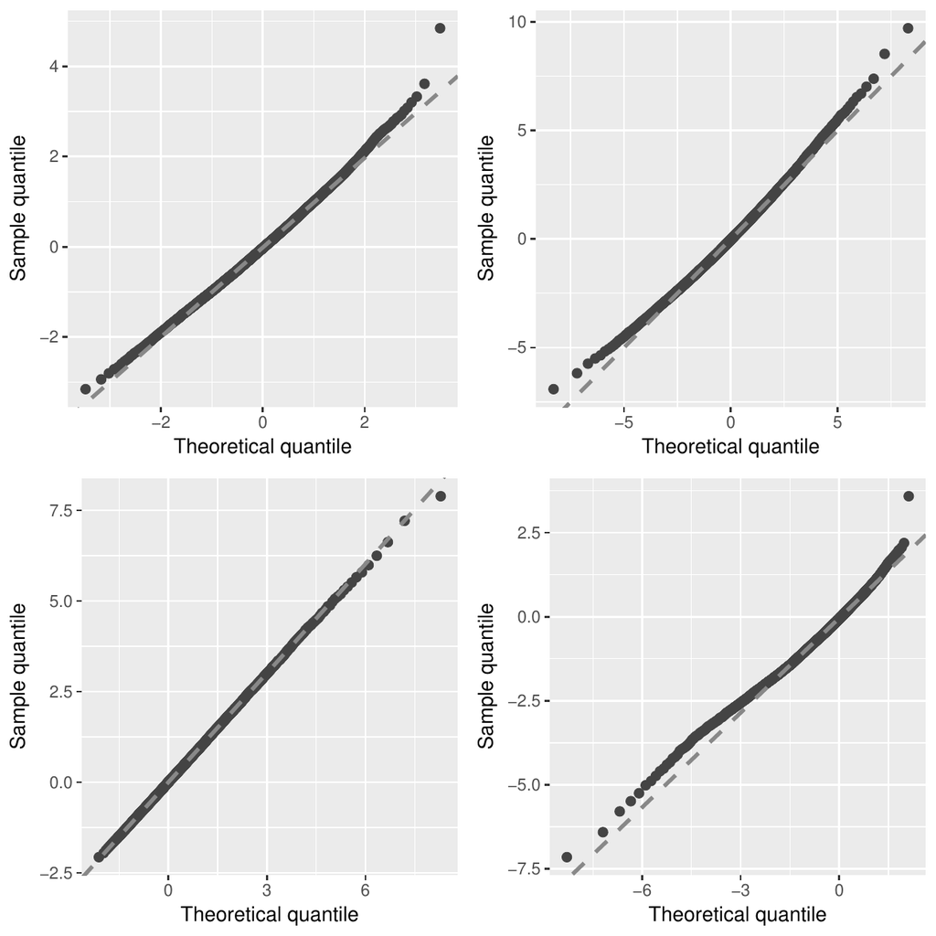

Figure 6: Q-Q plots of the residuals for various cumulative link models fit to simulated data with Gumbel (max) errors. *Top left*: A model with probit link. *Top right*: A model with logit link. *Bottom left*: A model with log-log link (i.e., the correct model). *Bottom right*: A model with complementary log-log link.

Alternatively, we could also use the surrogate residuals to make use of existing distance-based goodness-of-fit (GOF) tests; for example, the Kolmogorov-Smirnov distance. The `gof` function in *sure* can be used to produce simulated $p$-values from such tests.

Currently, the `gof` function supports three goodness-of-fit tests: the Kolmogorov-Smirnov test (`test = "ks"`), the Anderson-Darling test (`test = "ad"`), and the Cramer-Von Mises test (`test = "cvm"`). Below, we use the `gof` function to simulate $p$-values from the Anderson-Darling test for each of the four models; we also set `nsim` to 100 to produce smoother plots and reduce the sampling error induced by the surrogate procedure. The `plot` method is then used to display the empirical distribution function (EDF) of the simulated $p$-values. A good fit would imply uniformly distributed $p$-values; hence, the EDF would be relatively straight with a slope of one. The results in Figure 7 agree with the Q-Q plots from Figure 6 in that the log-log link is the most appropriate for these data. (Note: the plotting method for `"gof"` objects uses base R graphics; hence, we can use the `par` function to set various graphical parameters.)

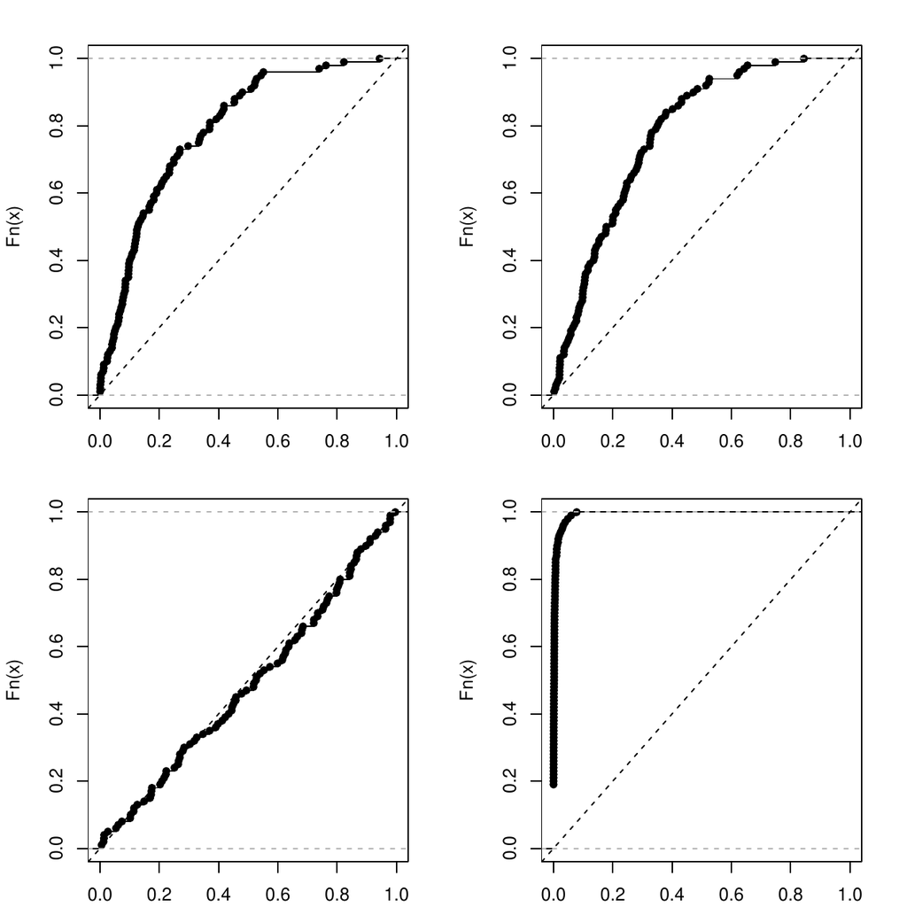

Figure 7: EDFs of the simulated $p$-values from an Anderson-Darling GOF test for various cumulative link models fit to simulated data with gumbel errors. *Top left*: A model with probit link. *Top right*: A model with logit link. *Bottom left*: A model with log-log link (i.e., the correct model). *Bottom right*: A model with complementary log-log link.

```r
# Figure 7
par(mfrow = c(2, 2), mar = c(2, 4, 2, 2) + 0.1)
set.seed(8491)  # for reproducibility
plot(gof(fit.probit, nsim = 100, test = "ad"), main = "")
plot(gof(fit.logistic, nsim = 100, test = "ad"), main = "")
plot(gof(fit.loglog, nsim = 100, test = "ad"), main = "")
plot(gof(fit.cloglog, nsim = 100, test = "ad"), main = "")
```

### 3.4 Checking the proportionality assumption

To illustrate, we generated 2000 observations from each of the following probit models
$$Pr\left(\mathcal{Y} \le j\right) = \Phi\left(\alpha_j + \beta_1 X\right), \quad j = 1, 2, 3, \quad \textrm{and} \quad Pr\left(\mathcal{Y} \le j\right) = \Phi\left(\alpha_j + \beta_2 X\right), \quad j = 4, 5, 6,$$
where $\alpha_1 = -1.5$, $\alpha_2 = 0$, $\alpha_3 = 1$, $\alpha_4 = 3$, $\beta_1 = 1$, $\beta_2 = 1.5$, and $X \sim \mathcal{U}\left(-3, 3\right)$. The data are available in the data frame `df4` within the package; see `?df4` for details.

```r
# Fit separate models (VGAM should already be loaded)
fit1 <- vglm(y ~ x, data = df4[1:2000, ],
             cumulative(link = probit, parallel = TRUE))
fit2 <- update(fit1, data = df4[2001:4000, ])

# Generate surrogate response values
set.seed(8671)  # for reproducibility
s1 <- surrogate(fit1)
s2 <- surrogate(fit2)

# Figure 8
ggplot(data.frame(D = s1 - s2, x = df4[1:2000, ]$x) , aes(x = x, y = D)) +
  geom_point(color = "#444444", shape = 19, size = 2) +
  geom_smooth(se = FALSE, size = 1.2, color = "red")
```

From Figure 8, it is clear that $\beta_1 - \beta_2 \ne 0$; hence, the proportionality assumption does not hold.

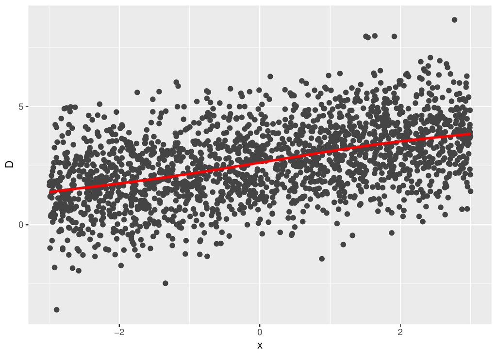

Figure 8: Scatterplot of $D = S_1 - S_2$ vs. $x$ with a nonparametric smooth (red curve).

### 3.5 Detecting interaction effects

A common challenge in model building is determining whether or not there are important interactions between the predictors in the data. Using the surrogate residuals, it is rather straightforward to determine if such an interaction effect is missing from the assumed model.

For illustration, we generated $n = 2000$ observations from the following ordered probit model
$$Pr\left(\mathcal{Y} \le j\right) = \Phi\left(\alpha_j + \beta_1 x_1 + \beta_2 x_2 + \beta_3 x_1 x_2\right), \quad j = 1, 2, 3, 4,$$
where $\alpha_1 = -16$, $\alpha_2 = -12$, $\alpha_3 = -8$, $\beta_1 = -5$, $\beta_2 = 3$, $\beta_3 = 10$, $x_1 \sim \mathcal{U}\left(1, 7\right)$, and $x_2$ is a factor with levels `Treatment` and `Control`. The simulated data are available in the `df5` data frame loaded with the *sure* package; see `?df5` for details. Below, we fit two probit models using the `clm` function from the *ordinal* package. The first model corresponds to the simulated control group, while the second model corresponds to the treatment group.

```r
library(ordinal)  # for clm function
fit1 <- clm(y ~ x1, data = df5[df5$x2 == "Control", ], link = "probit")
fit2 <- clm(y ~ x1, data = df5[df5$x2 == "Treatment", ], link = "probit")
```

If the true model contains an interaction term $x_1 x_2$ but the fitted model does not include it, we can detect this misspecification using the surrogate residuals. We simply plot $R_S$ versus $x_1$ for the treatment group, and compare it to the plot of $R_S$ versus $x_1$ for the controls—or better yet, we can just use the surrogate response $S$ instead of $R_S$. The trends in these two plots should be different. Below, we use `ggplot` along with the `sure` function to construct such a plot in Figure 9. The plot indicates a negative association between $x_1$ and the outcome within the control group, and a positive association between $x_1$ and the treatment group (i.e., an interaction between $x_1$ and $x_2$).

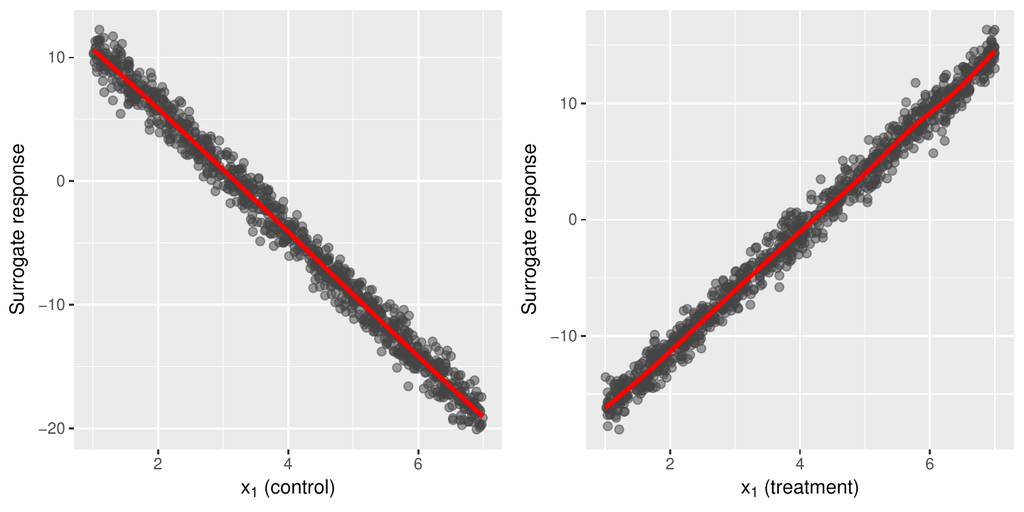

Figure 9: Scatterplot of the surrogate response $S$ versus $x_1$ with a nonparametric smooth (red line). *Left*: Control group. *Right*: Treatment group.

```r
# Figure 9
set.seed(1105)  # for reproducibility
df5$s <- c(surrogate(fit1), surrogate(fit2))  # surrogate response values
ggplot(df5, aes(x = x1, y = s)) +
  geom_point(color = "#444444", shape = 19, size = 2, alpha = 0.5) +
  geom_smooth(se = FALSE, size = 1.2, color = "red2") +
  facet_wrap( ~ x2) +
  ylab("Surrogate response") +
  xlab(expression(x[1]))
```

## 4 Bitterness of wine

Randall (1989) performed an experiment on factors determining the bitterness of wine. Two binary treatment factors, temperature and contact (between juice and skin), were controlled while crushing the grapes during wine production. Nine judges each assessed wine from two bottles from each of the four treatment conditions; for a total of $n = 72$. The response is an ordered factor with levels $1 < 2 < 3 < 4 < 5$. The data are available in the *ordinal* package; see ?`ordinal::wine` for details.

```r
data(wine, package = "ordinal")  # load wine data set
wine.clm <- clm(rating ~ temp + contact, data = wine, link = "probit")
```

Since both of the covariates in this model are binary factors, scatterplots are not appropriate for displaying the residual-by-covariate relationships. Instead, the `autoplot` function in `sure` uses boxplots; a future release is likely to include the additional option for producing nonparametric densities for each level of a factor. The code chunk below uses `autoplot` along with `grid.arrange` to produce some standard residual diagnostic plots. The results are displayed in Figure 10. The Q-Q plot and residual-vs-fitted value plot do not indicate any serious model misspecifications. Furthermore, the boxplots reveal that the medians of the surrogate residuals are very close to zero, and the distribution of the residuals within each level appear to be symmetric and have approximately the same variability (with the exception of a few outliers).

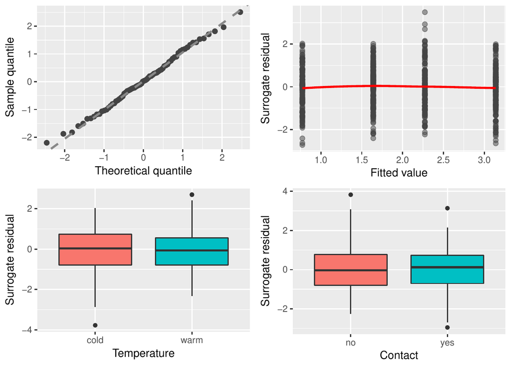

Figure 10: Residual diagnostic plots for the quality of wine example.

```r
set.seed(1225)  # for reproducibility
grid.arrange(  # Figure 10
  autoplot(wine.clm, nsim = 10, what = "qq"),
  autoplot(wine.clm, nsim = 10, what = "fitted", alpha = 0.5),
  autoplot(wine.clm, nsim = 10, what = "covariate", x = wine$temp,
           xlab = "Temperature"),
  autoplot(wine.clm, nsim = 10, what = "covariate", x = wine$contact,
           xlab = "Contact"),
  ncol = 2
)
```

## 5 Summary

In this paper, we introduce the *sure* package, which implements the surrogate approach to residuals for ordinal regression models described in Liu and Zhang (2017). Using simulated data sets, we illustrate the various properties of these residuals and how they can be used to check assumptions in the ordinal regression model (e.g., heteroscedasticity, misspecified link functions, etc.) using continuous residuals which produce diagnostic plots not unlike those seen in ordinary linear regression. This offers a new way of performing typical diagnostic checks for ordinal regression models that are easily interpreted by the analyst. Furthermore, this new approach to constructing residuals for ordinal regression models is still under active development and new functionality will be added to *sure* in the future.

## 6 Acknowledgments

The authors would like to thank the anonymous reviewers and the Editor for their helpful comments and suggestions.

### 6.1 Supplementary materials

Supplementary materials are available in addition to this article. It can be downloaded at RJ-2018-004.zip

### 6.2 CRAN packages used

MASS, VGAM, ordinal, rms, PResiduals, sure, ggplot2

### 6.3 CRAN Task Views implied by cited packages

ChemPhys, Distributions, Econometrics, Environmetrics, ExtremeValue, MixedModels, NetworkAnalysis, NumericalMathematics, Phylogenetics, Psychometrics, ReproducibleResearch, Robust, Spatial, Survival, TeachingStatistics

A. Agresti. *Analysis of ordinal categorical data.* John Wiley & Sons, 2010.

R. H. B. Christensen. *Ordinal—regression models for ordinal data.* 2015. URL http://www.cran.r-project.org/package=ordinal. R package version 2015.6-28.

C. Dupont, J. Horner, C. Li, Q. Liu and B. Shepherd. *PResiduals: Probability-scale residuals and residual correlations.* 2016. URL https://CRAN.R-project.org/package=PResiduals. R package version 0.2-4.

B. Efron. Bootstrap methods: Another look at the jackknife. *Annals fo Statistics*, 7(1): 1–26, 1979. URL http://dx.doi.org/10.1214/aos/1176344552.

B. Greenwell, A. McCarthy and B. Boehmke. *Sure: Surrogate residuals for ordinal and general regression models.* 2017. URL https://CRAN.R-project.org/package=sure. R package version 0.1.2.9000.

F. E. Harrell. *Regression modeling strategies: With applications to linear models, logistic regression, and survival analysis.* Springer-Verlag, 2001.

F. E. Harrell. *Rms: Regression modeling strategies.* 2017. URL https://CRAN.R-project.org/package=rms. R package version 5.1-1.

C. Li and B. E. Shepherd. A new residual for ordinal outcomes. *Biometrika*, 99(2): 473–480, 2012. URL http://dx.doi.org/10.1093/biomet/asr073.

D. Liu and H. Zhang. Residuals and diagnostics for ordinal regression models: A surrogate approach. *Journal of the American Statistical Association*, 0(ja): 0–0, 2017. URL http://dx.doi.org/10.1080/01621459.2017.1292915.

I. Liu, B. Mukherjee, T. Suesse, D. Sparrow and S. K. Park. Graphical diagnostics to check model misspecification for the proportional odds regression model. *Statistics in Medicine*, 28(3): 412–429, 2009. URL http://dx.doi.org/10.1080/01621459.2017.1292915.

J. H. Randall. The analysis of sensory data by generalized linear model. *Biometrical Journal*, 31(7): 781–793, 1989. URL http://dx.doi.org/10.1002/bimj.4710310703.

W. N. Venables and B. D. Ripley. *Modern applied statistics with s.* 4th ed New York: Springer-Verlag, 2002. URL http://www.stats.ox.ac.uk/pub/MASS4. ISBN 0-387-95457-0.

H. Wickham. *Ggplot2: Elegant graphics for data analysis.* Springer-Verlag, 2009. URL http://ggplot2.org.

T. W. Yee. *VGAM: Vector generalized linear and additive models.* 2017. URL https://CRAN.R-project.org/package=VGAM. R package version 1.0-3.